### Question 1

Consider the following 2D dataset:

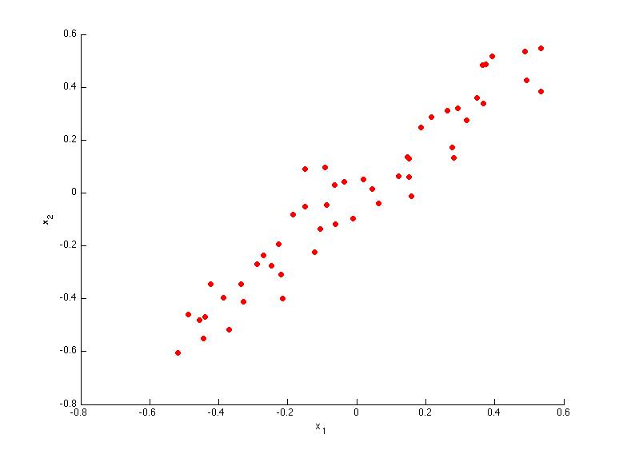

Which of the following figures correspond to possible values that PCA may return for $$u^{(1)}$$ (the first eigenvector / first principal component)? Check all that apply (you may have to check more than one figure).

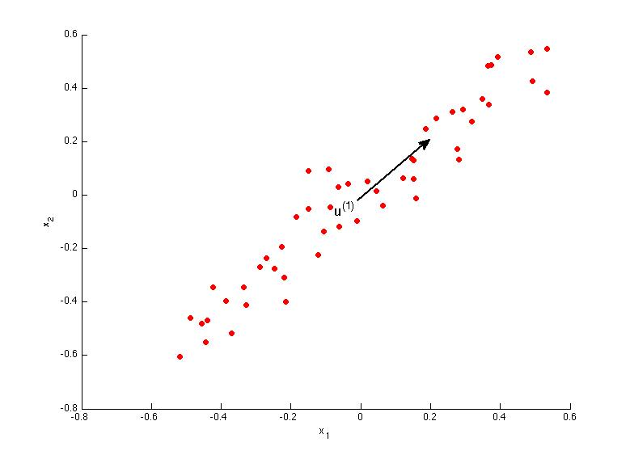

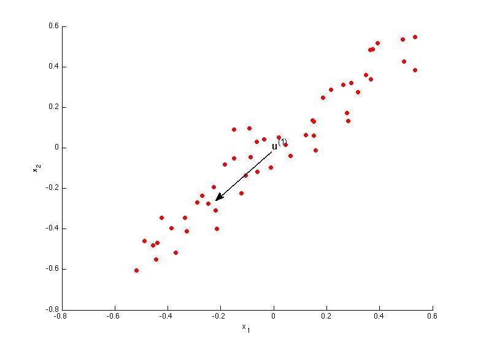

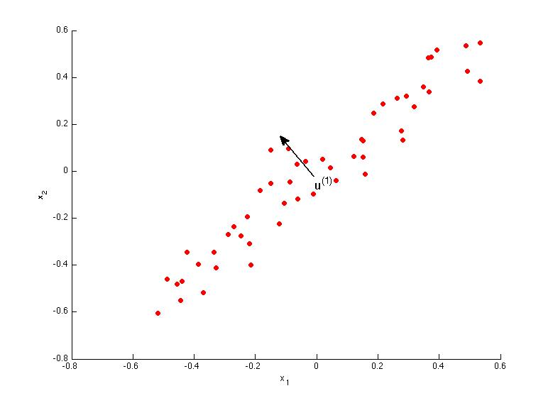

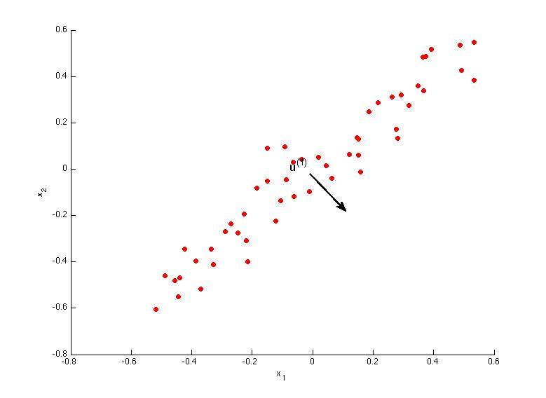

### Question 2

Which of the following is a reasonable way to select the number of principal components $$k$$?

(Recall that $$n$$ is the dimensionality of the input data and $$m$$ is the number of input examples.)

Choose $$k$$ to be 99% of $$m$$ (i.e., $$k = 0.99*m$$, rounded to the nearest integer).
Use the elbow method.
Choose $$k$$ to be the smallest value so that at least 99% of the variance is retained.
Choose $$k$$ to be the largest value so that at least 99% of the variance is retained

### Question 3

Suppose someone tells you that they ran PCA in such a way that "95% of the variance was retained." What is an equivalent statement to this?

$$\frac{ \frac{1}{m} \sum_{i=1}^m ||x^{(i)}- x^{(i)}_{\rm approx}||^2}{\frac{1}{m} \sum_{i=1}^m ||x^{(i)}||^2} \geq 0.95$$
$$\frac{ \frac{1}{m} \sum_{i=1}^m ||x^{(i)}- x^{(i)}_{\rm approx}||^2}{\frac{1}{m} \sum_{i=1}^m ||x^{(i)}||^2} \geq 0.05$$
$$\frac{ \frac{1}{m} \sum_{i=1}^m ||x^{(i)}- x^{(i)}_{\rm approx}||^2}{\frac{1}{m} \sum_{i=1}^m ||x^{(i)}||^2} \leq 0.05$$
$$\frac{\frac{1}{m} \sum_{i=1}^m ||x^{(i)}||^2}{\frac{1}{m} \sum_{i=1}^m ||x^{(i)}- x^{(i)}_{\rm approx}||^2} \geq 0.95$$

### Question 4

Which of the following statements are true? Check all that apply.

Given an input $$x \in \mathbb{R}^n$$, PCA compresses it to a lower-dimensional vector $$z \in \mathbb{R}^k$$.
PCA can be used only to reduce the dimensionality of data by 1 (such as 3D to 2D, or 2D to 1D).
Feature scaling is not useful for PCA, since the eigenvector calculation (such as using Octave's $${\tt svd(Sigma)}$$ routine) takes care of this automatically.
If the input features are on very different scales, it is a good idea to perform feature scaling before applying PCA.

### Question 5

Which of the following are recommended applications of PCA? Select all that apply.

Clustering: To automatically group examples into coherent groups.
Data compression: Reduce the dimension of your input data $$x^{(i)}$$, which will be used in a supervised learning algorithm (i.e., use PCA so that your supervised learning algorithm runs faster).
To get more features to feed into a learning algorithm.
Data visualization: Reduce data to 2D (or 3D) so that it can be plotted.